# ANOVA

Examples using R

Ranadeep Daw

2024-11-22

## Question 1

### Researchers conducted a study on 90 patients to investigate the effects of two factors, `Treatment` and `Age Group`, on recovery time after surgery. `Treatment` has three types: “standard”, “new-drug”, and “alternative-therapy”. `Age Group` has three levels: “young”, “middle-aged”, and “elderly”. Below is an incomplete two-way ANOVA table with interaction summarizing the results. What are the values of A – K?

| Source | Df | Sum Sq | Mean Sq | F value |
| --- | --- | --- | --- | --- |
| Treatment | 3-1 = 2 | 3600- (170 + 200 + 1620) = 1610 | 1610/2 = 805 | 805/20 = 40.25 |
| Age Group | 3-1 =2 | 85 * 2 = 170 | 85 | 85/20 = 4.25 |
| Treatment:Age Group | 2* 2 = 4 | 200 | 200/4 = 50 | 50/20 = 2.5 |
| Residuals | 89 - 2 -2 -4 = 81 | 81 * 20 = 1620 | 20 |  |
| **Total** | 90 -1 = 89 | **3600** |  |  |

**Answer:** Keep these key formulae in mind:

1. **Degrees of freedom for the main effects**:  
   $\text{df}_{\text{Any main effect}} = \text{number of levels} - 1$
2. **Interaction degrees of freedom** (for interaction models):  
   $\text{df}_{\text{Interaction term}} = \text{Product of the main effect degrees of freedom}$
3. **Total Sum of Squares (SST)**:  
   $\text{SST} = \text{SSA} + \text{SSB} + \text{SSAB} + \text{SSE}$
4. **Mean Squares (MS)**:  
   $\text{MS}_{X} = \frac{\text{SS}_{X}}{\text{df}_{X}}$
5. **F-statistic for any component**:  
   $F_{X} = \frac{\text{MS}_{X}}{\text{MSE}}$

## Question 2[^1]

### Use the following data called `fruit_data`. The response variable here is `Yield`: the yield of fruits from three varieties of a citrus tree. The two categorical predictors here are `Var` (variety) and `Pest` (type of pesticide).

```r
Pesticide <- factor(c('A','B','C','D'))
Variety <- factor(c('1','2','3'))
fruit_data <- data.frame( expand.grid(rep=1:2, Pest=Pesticide, Var=Variety) )
fruit_data$Yield <- c(49,39,50,55,43,38,53,48,55,41,67,58,53,42,85,73,66,68,85,92,69,62,85,99)
fruit_data
```

```
##    rep Pest Var Yield
## 1    1    A   1    49
## 2    2    A   1    39
## 3    1    B   1    50
## 4    2    B   1    55
## 5    1    C   1    43
## 6    2    C   1    38
## 7    1    D   1    53
## 8    2    D   1    48
## 9    1    A   2    55
## 10   2    A   2    41
## 11   1    B   2    67
## 12   2    B   2    58
## 13   1    C   2    53
## 14   2    C   2    42
## 15   1    D   2    85
## 16   2    D   2    73
## 17   1    A   3    66
## 18   2    A   3    68
## 19   1    B   3    85
## 20   2    B   3    92
## 21   1    C   3    69
## 22   2    C   3    62
## 23   1    D   3    85
## 24   2    D   3    99
```

### a. Test the hypothesis that there is no difference between the different pesticide effects on Yield. You need to build the interaction plot, build the appropriate ANOVA table, state the hypotheses, and then conduct the test.

**Answer:**

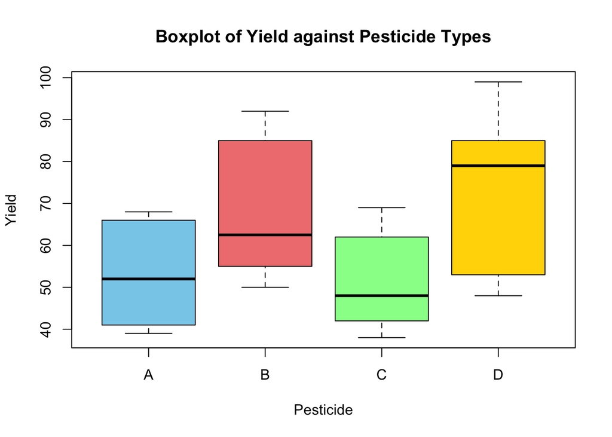

```r
boxplot(Yield ~ Pest, data = fruit_data,
        col = c("skyblue", "lightcoral", "palegreen", "gold"),
        xlab = "Pesticide",
        main = "Boxplot of Yield against Pesticide Types")
```

```r
model1 = lm(Yield ~ Pest, data = fruit_data)
summary.aov(model1)
```

```
##             Df Sum Sq Mean Sq F value Pr(>F)
## Pest         3   2227   742.5   2.994 0.0552 .
## Residuals   20   4960   248.0
## ---
## Signif. codes:  0 '***' 0.001 '**' 0.01 '*' 0.05 '.' 0.1 ' ' 1
```

- $H_0$: Effect of Pesticide type A = Effect of Effect of Pesticide type B = Effect of Pesticide type C = Effect of Pesticide type D.
- $H_A$: At least one of them is different from others.
- F statistic = 2.994.
- $p$ value = 0.0552 > $\alpha$ = 0.05. Hence, we can not reject $H_0$.
- To interpret, we don’t have enough evidence to claim that different pesticides have a different effect on the response variable, `Yield`.

### b. Do you need to perform a Tukey’s HSD test here? Irrespective of the answer, perform the test and comment on the findings.

**Answer:** We do not need to do a posthoc analysis here since the F test was not rejected. However, let’s still try to see what the Tukey’s HSD test gives us.

```r
TukeyHSD(aov(model1))
```

```
##   Tukey multiple comparisons of means
##     95% family-wise confidence level
##
## Fit: aov(formula = model1)
##
## $Pest
##           diff        lwr       upr     p adj
## B-A  14.833333 -10.616216 40.282882 0.3845183
## C-A  -1.833333 -27.282882 23.616216 0.9969999
## D-A  20.833333  -4.616216 46.282882 0.1336903
## C-B -16.666667 -42.116216  8.782882 0.2878026
## D-B   6.000000 -19.449549 31.449549 0.9108137
## D-C  22.666667  -2.782882 48.116216 0.0917438
```

As expected in part A, none of the pairwise differences are statistically significant. Tukey’s test, which assumes the null hypothesis of no difference between two levels, confirms this as all $p$-values are greater than the significance level ($α=0.05$).

### c. Test the hypothesis that there is no difference in `Yield` among the varieties (Variable `Var`) of the trees. Again, you need to build the interaction plot, build the appropriate ANOVA table, state the hypotheses, and then conduct the test.

**Answer:**

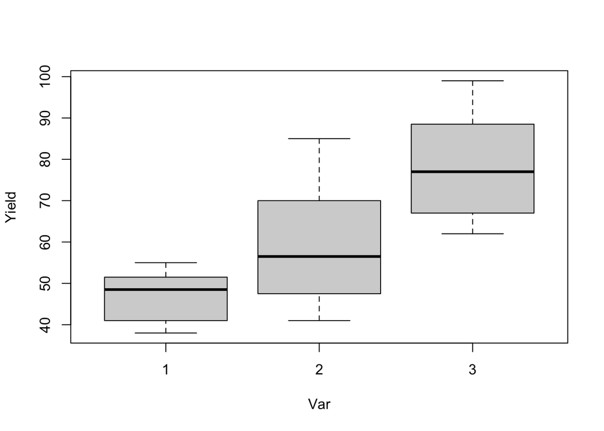

```r
boxplot(Yield ~ Var, data = fruit_data)
```

```r
model2 = lm(Yield ~ Var, data = fruit_data)
summary.aov(model2)
```

```
##             Df Sum Sq Mean Sq F value   Pr(>F)
## Var          2   3996    1998   13.15 0.000199 ***
## Residuals   21   3192     152
## ---
## Signif. codes:  0 '***' 0.001 '**' 0.01 '*' 0.05 '.' 0.1 ' ' 1
```

- $H_0$: Effect of Variety type 1 = Effect of Effect of Variety type 2 = Effect of Variety type 3.
- $H_A$: At least one of them is different from others.
- F statistic = $13.15$.
- $p$ value = 0.0002 < $\alpha$ = 0.05. Hence, we can reject $H_0$.
- To interpret our F test, there is sufficient evidence to conclude that different varieties lead to different yields.

### d. Do you need to perform a Tukey’s HSD test for part (c)? Irrespective of the answer, perform the test and comment on the findings.

**Answer:**

Since F test led to a rejection of $H_0$, we need to peform Tukey’s test here.

```r
TukeyHSD( aov(model2))
```

```
##   Tukey multiple comparisons of means
##     95% family-wise confidence level
##
## Fit: aov(formula = model2)
##
## $Var
##       diff       lwr      upr     p adj
## 2-1 12.375 -3.162534 27.91253 0.1350549
## 3-1 31.375 15.837466 46.91253 0.0001383
## 3-2 19.000  3.462466 34.53753 0.0149567
```

We see that at $\alpha = 0.05$, effect of variety type 3 is statistically different from the other two (see the correspoding p values in the `p adj` column). However, no difference found between variety 1 and 2.

### e. Build the two way additive ANOVA model and the corresponding interaction plot. Which predictor(s) is/are significant in this model? Do the Tukey’s HSD test afterwards and comment what you found.

**Answer:**

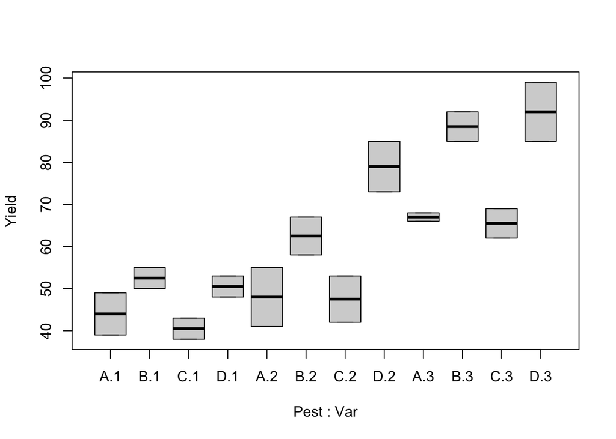

```r
boxplot( Yield ~ Pest + Var, data = fruit_data)
```

```r
model3 = lm(Yield ~ Pest + Var, data = fruit_data)
summary.aov(model3)
```

```
##             Df Sum Sq Mean Sq F value   Pr(>F)
## Pest         3   2227   742.5   13.86 6.31e-05 ***
## Var          2   3996  1998.0   37.29 3.97e-07 ***
## Residuals   18    964    53.6
## ---
## Signif. codes:  0 '***' 0.001 '**' 0.01 '*' 0.05 '.' 0.1 ' ' 1
```

We can perform F-tests similar to those in parts A and C, so they are not repeated here. However, it is important to note that **`Pesticide` becomes a significant variable** when `Variety` is included in the model, unlike the results in part A.

Let’s perform the Tukey’s test to check the mutual differences further.

```r
TukeyHSD( aov(model3))
```

```
##   Tukey multiple comparisons of means
##     95% family-wise confidence level
##
## Fit: aov(formula = model3)
##
## $Pest
##           diff        lwr       upr     p adj
## B-A  14.833333   2.889267 26.777399 0.0121713
## C-A  -1.833333 -13.777399 10.110733 0.9718552
## D-A  20.833333   8.889267 32.777399 0.0005728
## C-B -16.666667 -28.610733 -4.722601 0.0047986
## D-B   6.000000  -5.944066 17.944066 0.5037838
## D-C  22.666667  10.722601 34.610733 0.0002286
##
## $Var
##       diff       lwr      upr     p adj
## 2-1 12.375  3.034405 21.71559 0.0088734
## 3-1 31.375 22.034405 40.71559 0.0000003
## 3-2 19.000  9.659405 28.34059 0.0001735
```

See that some pesticide types now exhibit significantly different effects on the response (again, check $p$ values). Additionally, all the varieties now show statistically significant differences from one another, unlike the result in part D, where varieties 1 and 2 did not have statistically different effects.

### f. Build the two way ANOVA model with interaction. Is the interaction term necessary in the model?

**Answer:**

```r
model4 = lm(Yield ~ Pest * Var, data = fruit_data)
summary.aov(model4)
```

```
##             Df Sum Sq Mean Sq F value   Pr(>F)
## Pest         3   2227   742.5  17.556  0.00011 ***
## Var          2   3996  1998.0  47.244 2.05e-06 ***
## Pest:Var     6    457    76.2   1.801  0.18168
## Residuals   12    508    42.3
## ---
## Signif. codes:  0 '***' 0.001 '**' 0.01 '*' 0.05 '.' 0.1 ' ' 1
```

Let’s formally write down the test for interaction effects.

- $H_0$: The interaction term is not significant, or, there are no interaction effects between the two predictors `Pesticide` and `Variety`.
- $H_A$: The interaction term is significant, or, there are interaction effects between the two predictors `Pesticide` and `Variety`.
- $F$ statistic = $1.801.
- p value = $0.18168$ > $\alpha$. Hence, we do not need the interaction term in our model.

Now let’s do the Tukey’s test. Since both the main effects are significant, you can expect some pairwise differences to be significant with very small p values. For the interaction term, although the interaction effect is insignificant, it may still result in some differences that are significantly different from 0 in Tukey’s test. See below:

```r
TukeyHSD(aov(model4))
```

```
##   Tukey multiple comparisons of means
##     95% family-wise confidence level
##
## Fit: aov(formula = model4)
##
## $Pest
##           diff        lwr       upr     p adj
## B-A  14.833333   3.686218 25.980449 0.0090010
## C-A  -1.833333 -12.980449  9.313782 0.9602336
## D-A  20.833333   9.686218 31.980449 0.0006293
## C-B -16.666667 -27.813782 -5.519551 0.0038826
## D-B   6.000000  -5.147116 17.147116 0.4155094
## D-C  22.666667  11.519551 33.813782 0.0002965
##
## $Var
##       diff       lwr      upr     p adj
## 2-1 12.375  3.700169 21.04983 0.0065387
## 3-1 31.375 22.700169 40.04983 0.0000015
## 3-2 19.000 10.325169 27.67483 0.0002163
##
## $`Pest:Var`
##          diff         lwr       upr     p adj
## B:1-A:1   8.5 -17.3187287 34.318729 0.9623243
## C:1-A:1  -3.5 -29.3187287 22.318729 0.9999793
## D:1-A:1   6.5 -19.3187287 32.318729 0.9944603
## A:2-A:1   4.0 -21.8187287 29.818729 0.9999239
## B:2-A:1  18.5  -7.3187287 44.318729 0.2694999
## C:2-A:1   3.5 -22.3187287 29.318729 0.9999793
## D:2-A:1  35.0   9.1812713 60.818729 0.0054853
## A:3-A:1  23.0  -2.8187287 48.818729 0.0982919
## B:3-A:1  44.5  18.6812713 70.318729 0.0006597
## C:3-A:1  21.5  -4.3187287 47.318729 0.1394250
## D:3-A:1  48.0  22.1812713 73.818729 0.0003202
## C:1-B:1 -12.0 -37.8187287 13.818729 0.7699402
## D:1-B:1  -2.0 -27.8187287 23.818729 0.9999999
## A:2-B:1  -4.5 -30.3187287 21.318729 0.9997682
## B:2-B:1  10.0 -15.8187287 35.818729 0.9023986
## C:2-B:1  -5.0 -30.8187287 20.818729 0.9993938
## D:2-B:1  26.5   0.6812713 52.318729 0.0423795
## A:3-B:1  14.5 -11.3187287 40.318729 0.5595045
```

[output cut: 33 more lines]

```
## D:2-C:2  31.5   5.6812713 57.318729 0.0125983
## A:3-C:2  19.5  -6.3187287 45.318729 0.2179983
## B:3-C:2  41.0  15.1812713 66.818729 0.0014023
## C:3-C:2  18.0  -7.8187287 43.818729 0.2985804
## D:3-C:2  44.5  18.6812713 70.318729 0.0006597
## A:3-D:2 -12.0 -37.8187287 13.818729 0.7699402
## B:3-D:2   9.5 -16.3187287 35.318729 0.9263730
## C:3-D:2 -13.5 -39.3187287 12.318729 0.6454346
## D:3-D:2  13.0 -12.8187287 38.818729 0.6881330
## B:3-A:3  21.5  -4.3187287 47.318729 0.1394250
## C:3-A:3  -1.5 -27.3187287 24.318729 1.0000000
## D:3-A:3  25.0  -0.8187287 50.818729 0.0609485
## C:3-B:3 -23.0 -48.8187287  2.818729 0.0982919
## D:3-B:3   3.5 -22.3187287 29.318729 0.9999793
## D:3-C:3  26.5   0.6812713 52.318729 0.0423795
```

[^1]: Courtesy: Statistical Methods II by Derek L. Sonderegger, taken from [here]https://bookdown.org/dereksonderegger/571/6-two-way-anova.html#two-way-anova-1